# Math 120 Week 02

Prof Miller

31 January, 2020

# Tuesday

Goals:

- Center, Shape, and Spread for Quantitative Variables
- Outliers, boxplots

Measures of center: tell what’s “normal”.

Definition: a measure is *robust* if it’s not strongly affected by outliers/skew.

Example: median is robust (not affected by outliers), but mean is *NOT* robust. Example: 1, 1, 1, 1, 1, 19.

## Shape of a distribution

Common shapes:

- Symmetric. Evenly distributed on either side of the middle.
- Left skew (left tail)
- Right skew (right tail)

### Exercise: What shape?

Based on the following, what shape does the variable have and how do the mean and median compare?

1. Variable: Exam scores in a large class for an easy exam. Shape: left skew, most students scored well, only a few scored poorly. We’d expect the mean score to lower than the median.
2. Variable: salaries in a large corporation. Strong right skew! Most employees earn a “normal” amount, a select few earn much more. Ex: In 2018, revealed that the CEO of Activision earned 300x the average salary! The mean salary will be a lot larger, could skew our perception of wealth in the corporation.
3. Variable: height of adult men in the US. Symmetric dist! Most people have “average” height, only a few are exceptionally tall or short. We’d expect that the mean and median are similar.
4. Variable: heights of all adults in the US, men and women. Shape: bimodal. Still fairly symmetric, since 50/50 gender.

## Measures of Spread (quantitative variable)

I.e., how much variability? How far away do we expect observations to be from the center?

Three big measures:

1. Range: max - min

Example: range of sepal lengths:

```r
summary(iris$Sepal.Length)
```

```
##    Min. 1st Qu.  Median    Mean 3rd Qu.    Max.
##   4.300   5.100   5.800   5.843   6.400   7.900
```

Range: 3.6cm. Advantage: easy! Big disadvantage: super, duper, extra not robust!!! Even one outlier wrecks the range.

2. Standard deviation. The “deviation” for an observation is just it’s distance from the mean: x - xbar. For std deviation, we find all deviations for all observations, and (roughly) take their average. Std dev = average distance from the center.

Formula:

$$s=\sqrt{\sum\frac{(x-\bar{x})^2}{n-1}}$$

3. Interquartile Range = The distance between the quartiles Q1 and Q3. Note: Q1 is the median of the lower half. Q3 is the median of the upper half). IQR gives us the range/spread of the middle 50% of the data.

Interesting note: all three of these are totally different approaches, but they’re all reasonable ways to measure spread.

Q: Which of the three measures of spread is “robust”?  
A: Only the IQR, since it’s determined by the middle stuff. Outliers have no effect.

## Outliers

Outliers are “unusual” measurements! Couple of different methods for determining. Here’s ours:

We’ll define an outlier to be any measurement that’s more than 1.5 IQRs away from Q1 or Q3.

Low cutoff:
$$Q1 - 1.5\cdot IQR$$

high cutoff:
$$Q3 + 1.5\cdot IQR$$

**Example** Verify that 20 is an outlier in 1,2,3,4,5,20.

## Boxplots

Boxplots visualize the IQR. Super useful for comparing multiple quant. variables, since it’s easy to have multiple boxplots on the same axes.

Example: Iris dataset

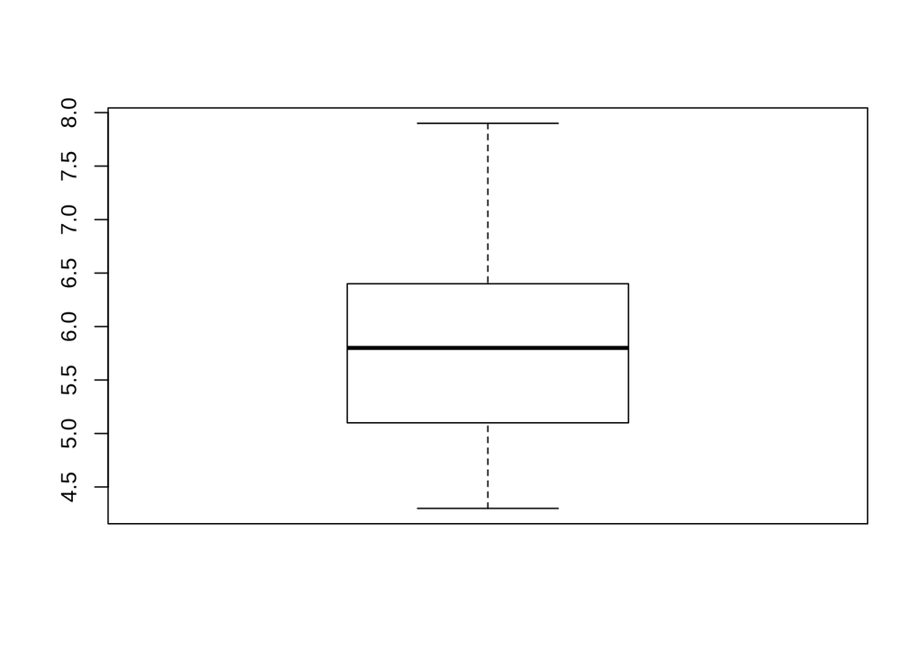

```r
boxplot(iris$Sepal.Length)
```

Comparing all variables:

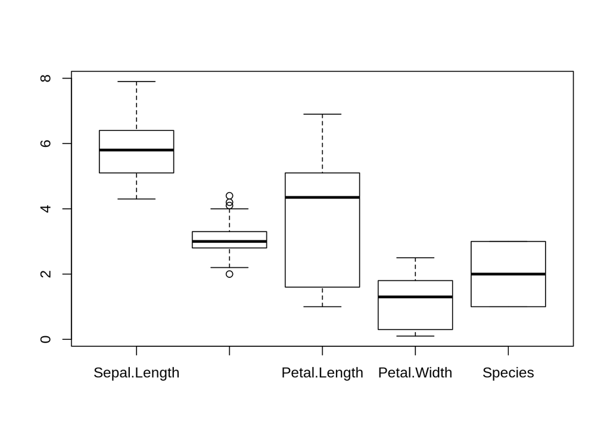

```r
boxplot(iris)
```

Comparing by species:

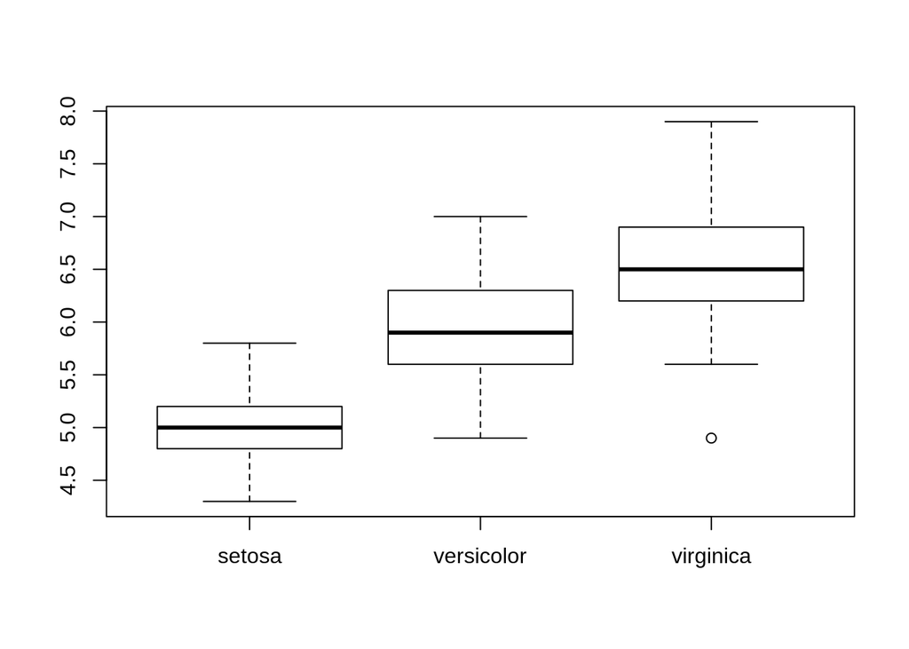

```r
boxplot(data=iris, Sepal.Length~Species)
```

# Wednesday

## Goals

- Weird Plots
- Empirical Rule
- Meaning of “Statistical Inference”

## Weird plots

We’ve seen some “typical” plots. Example, iris data:

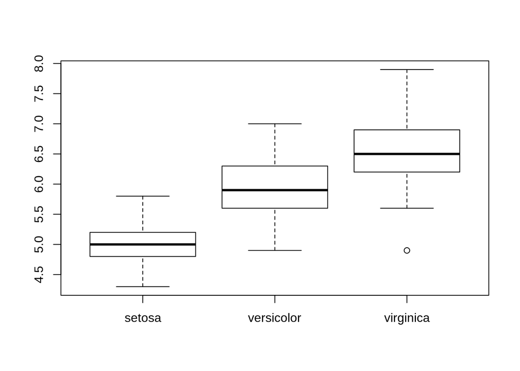

```r
boxplot(data=iris, Sepal.Length~Species)
```

Q: which species has the highest center? Virginica!

Q: which species has the smallest spread? Setosa sepal lengths have least variability.

Q: Outliers? Looks like virginica has one low outlier.

## Weird example: Cirp Survey Data

Take a look:

```r
cirpData <- read.csv("CIRP_DATA_2014_CLEAN.csv")
head(cirpData)
```

|  | SEX | HSGPA | YRSTUDY1 | YRSTUDY2 | YRSTUDY4 | YRSTUDY5 | YRSTUDY8 | RATE01 | RATE03 | RATE07 | RATE08 | RATE10 | RATE11 | RATE13 | RATE14 | RATE15 | RATE16 | RATE20 | HPW01 | HPW02 | HPW04 | HPW06 | HPW07 | HPW08 | HPW09 | HPW11 | HPW12 | HPW13 |
| --- | --- | --- | --- | --- | --- | --- | --- | --- | --- | --- | --- | --- | --- | --- | --- | --- | --- | --- | --- | --- | --- | --- | --- | --- | --- | --- | --- | --- |
| 1 | male | 7 | 6 | 6 | 6 | 4 | 6 | 4 | 3 | 4 | 5 | 3 | 4 | 5 | 4 | 4 | 3 | 4 | 7 | 6 | 6 | 3 | 4 | 5 | 2 | 2 | 2 | 3 |
| 2 | female | 8 | 6 | 6 | 3 | 5 | 6 | 5 | 4 | 3 | 3 | 5 | 3 | 2 | 2 | 4 | 3 | 3 | 5 | 5 | 6 | 3 | 2 | 4 | 1 | 3 | 1 | 5 |
| 3 | female | 8 | 6 | 6 | 4 | 4 | 6 | 4 | 4 | 4 | 4 | 3 | 5 | 3 | 3 | 3 | 3 | 4 | 8 | 4 | 6 | 1 | 1 | 3 | 2 | 1 | 1 | 4 |
| 4 | male | 7 | 6 | 7 | 4 | 4 | 6 | 4 | 5 | 4 | 4 | 4 | 4 | 4 | 4 | 4 | 3 | 3 | 2 | 5 | 4 | 2 | 1 | 3 | 5 | 2 | 1 | 3 |
| 5 | female | 6 | 6 | 6 | 6 | 3 | 1 | 4 | 3 | 4 | 4 | 2 | 4 | 2 | 1 | 4 | 2 | 4 | 7 | 8 | 8 | 1 | 4 | 1 | 5 | 4 | 1 | 7 |
| 6 | female | 5 | 6 | 6 | 4 | 3 | 4 | 3 | 5 | 5 | 2 | 3 | 4 | 4 | 5 | 3 | 5 | 3 | 3 | 7 | 2 | 7 | 3 | 3 | 6 | 2 | 1 | 7 |

Note: totally need metadata.

Q: what about english? How much english have DU students had?

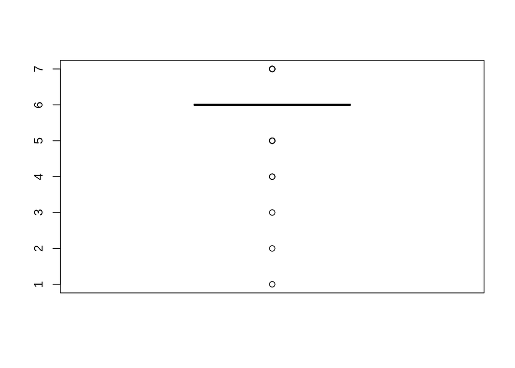

```r
boxplot(cirpData$YRSTUDY1)
```

Analysis: almost everyone responded 6, i.e., the vast majority of incoming DU students took 4 years of english in HS. Q1 = M = Q3 = 6.

## Another weird example: scatterplot

Q: Is there a relationship between RATE01 (academic ability) and RATE03 (competitiveness)?

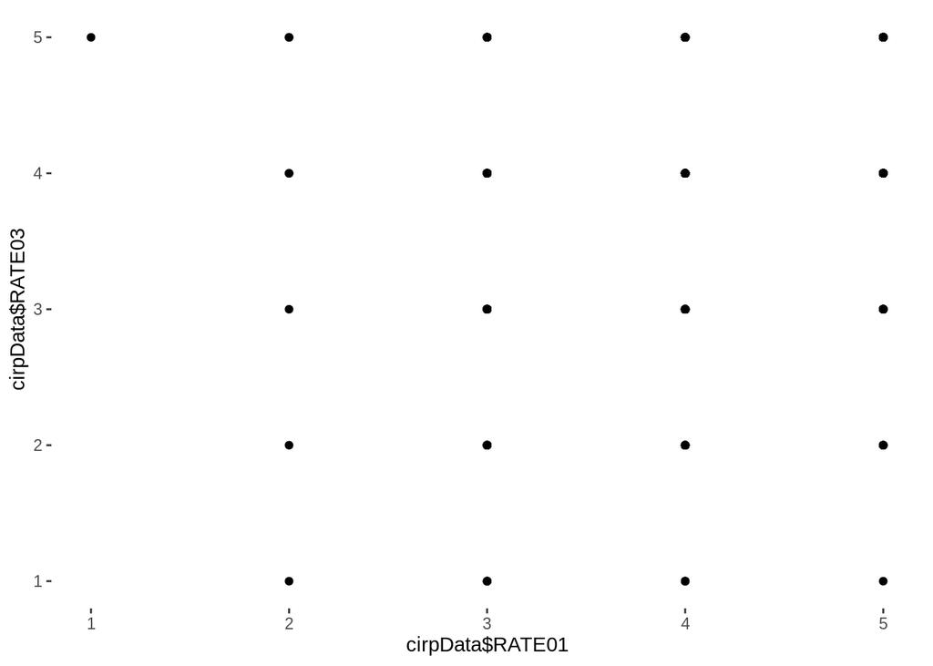

```r
qplot(cirpData$RATE01, cirpData$RATE03)
```

Woah! weird! What’s going on? Discrete data often doesn’t work well with scatterplots. Can’t tell how many points!

Neat trick: jitter. “Jittering” means adding a small amount of random noise.

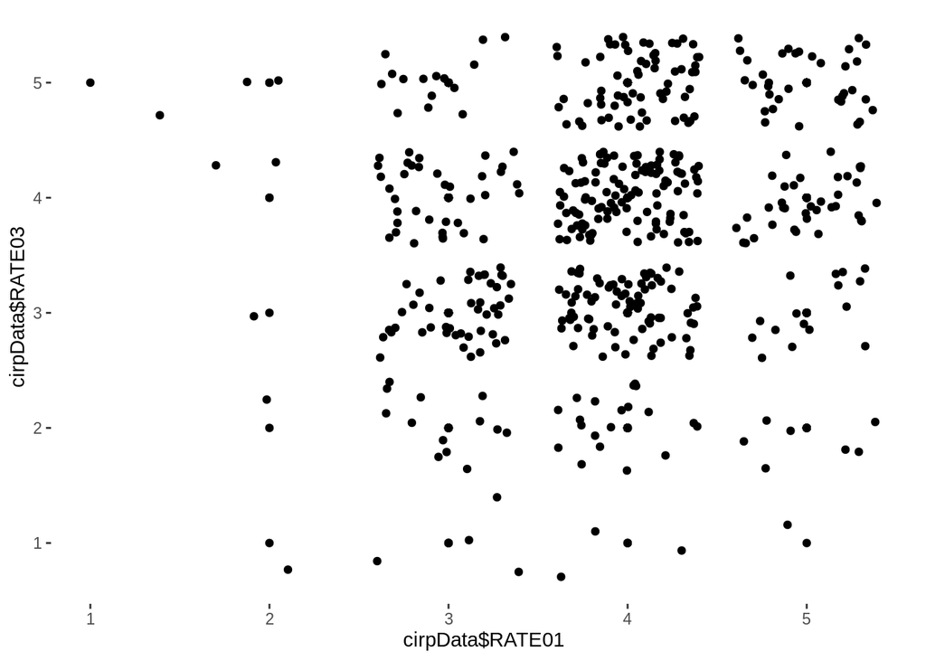

```r
qplot(cirpData$RATE01, cirpData$RATE03)+geom_jitter()
```

Ah! Now we can see a roughly positive pattern.

Moral of the story: think carefully about any visualition you do. What’s it mean?

## Example: Exam scores

66, 67, 71, 71, 74, 76, 76, 78, 80, 99

Check for outliers, make a boxplot, describe shape.

IQR: 7, Q1 = 71, Q3 = 78

Low cutoff:

```r
71 - 1.5*7
```

```
## [1] 60.5
```

High cutoff:

```r
78+1.5*7
```

```
## [1] 88.5
```

Note: 99 is an outlier!

Warning for boxplot: draw axis first!

Shape: aside from outlier, there’s a little left skew.

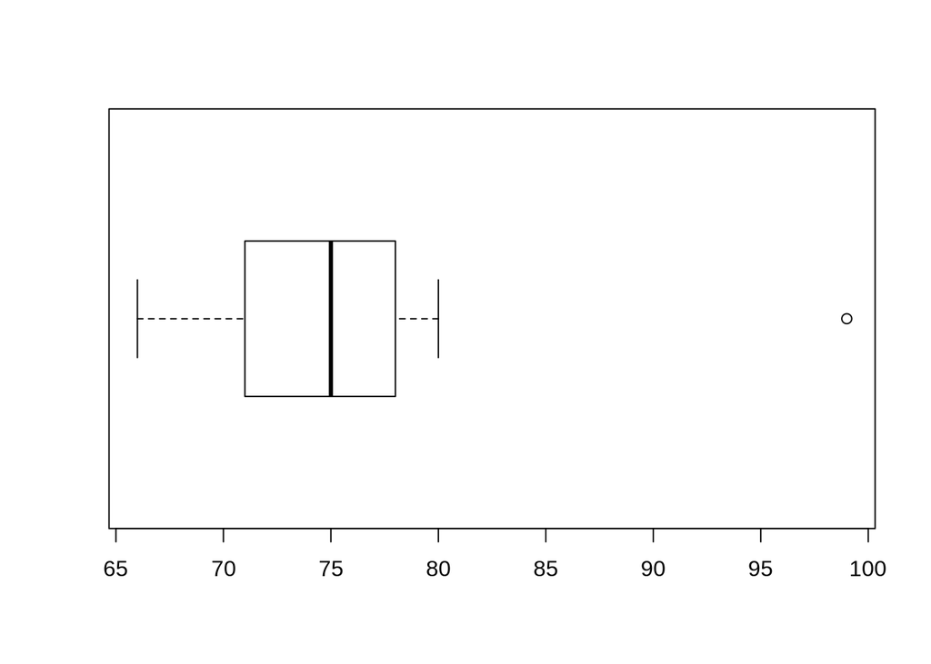

```r
boxplot(c(66, 67, 71, 71, 74, 76, 76, 78, 80, 99), horizontal = TRUE)
```

## Empirical Rule and Z scores

We know about outliers, but what about everything else? Common question: how “unusual” is a measurement in our data?

Major tool: z scores (standard scores).

Z scores measure the distance from a point to the mean, in units of standard deviation! I.e., how many standard deviations above or below the mean are you?

Example: Adult women in the US have mean height 64" with std dev 2.4" (true). Prof miller 75". Compute her z score!

```r
(75-64)/2.4
```

```
## [1] 4.583333
```

Note about rounding: three decimals is enough.

Why is this useful? It lets us compare elements of different datasets! It accounts for the center and spread of the respective distributions.

Example: Exam scores. On ACT, the mean score for test takers is 24, std dev 3. On SAT, the mean score is 680, with std dev 40.

If Alex got a 28 on the ACT, and Beth got 720 on the SAT, who scored better?

Z scores!

Alex:

```r
(28- 24)/3
```

```
## [1] 1.333333
```

Beth:

```r
(720-680)/40
```

```
## [1] 1
```